# Modelo SOI

Juan David Leongómez

2022-09-28

# 1 Cargar paquetes

```r
library(readxl)
library(car)
library(dplyr)
library(tidyr)
library(tibble)
library(stringr)
library(lmerTest)
library(interactions)
library(ggplot2)
library(report)
library(performance)
library(knitr)
library(kableExtra)
library(tidyquant)
library(equatiomatic)
```

# 2 Cargar base de datos

```r
bd <- read_excel("Base de datos_FIN.xlsx") |>
  mutate(Sexo = recode(Sexo,
                       "1" = "Hombre",
                       "2" = "Mujer")) |>
  mutate(across(where(is.character), as.factor))
```

## 2.1 Estructura base de datos

```r
str(bd)
```

```
## tibble [12,240 × 7] (S3: tbl_df/tbl/data.frame)
##  $ ID Participante: Factor w/ 136 levels "R_0U4PskIpHioyiUV",..: 73 73 73 73 73 73 73 73 73 73 ...
##  $ Edad           : num [1:12240] 25 25 25 25 25 25 25 25 25 25 ...
##  $ Sexo           : Factor w/ 2 levels "Hombre","Mujer": 1 1 1 1 1 1 1 1 1 1 ...
##  $ Canal          : Factor w/ 3 levels "Rostro","Voz",..: 2 2 2 2 2 2 2 2 2 2 ...
##  $ Estimulo       : Factor w/ 60 levels "H200","H203",..: 31 32 33 34 35 36 37 38 39 40 ...
##  $ SOI            : num [1:12240] 2.22 6.89 4.44 5 4.11 ...
##  $ Calificacion   : num [1:12240] 7.3 10 0 2.5 6 3.3 5 10 5.5 9.1 ...
```

### 2.1.1 Tabla descriptivos jueces

```r
bd |>
  drop_na(Calificacion) |>
  group_by(`ID Participante`, Sexo) |>
  summarise("Calificacion" = mean(Calificacion),
            "Edad" = mean(Edad)) |>
  group_by(Sexo) |>
  summarise("n" = length(Sexo),
            "Media" = mean(Edad),
            "DE" = sd(Edad),
            "Máxima" = max(Edad),
            "Mínima" = min(Edad),
            "Media2" = mean(Calificacion),
            "DE2" = sd(Calificacion),
            "Máxima2" = max(Calificacion),
            "Mínima2" = min(Calificacion)) |>
  kable(booktabs = TRUE,
        digits = 2,
        caption = "Descriptivos de edad y sociosexualidad estimada por los jueces",
        col.names = c(" ",
                      "n",
                      "Media", "DE", "Máxima", "Mínima",
                      "Media", "DE", "Máxima", "Mínima")) |>
  kable_classic("hover", full_width = FALSE) |>
  add_header_above((c(" " = 2, "Edad" = 4, "Estimación sociosexualidad" = 4)))
```

Descriptivos de edad y sociosexualidad estimada por los jueces

|  | n | Edad Media | Edad DE | Edad Máxima | Edad Mínima | Estimación sociosexualidad Media | Estimación sociosexualidad DE | Estimación sociosexualidad Máxima | Estimación sociosexualidad Mínima |
| --- | --- | --- | --- | --- | --- | --- | --- | --- | --- |
| Hombre | 68 | 22.75 | 3.35 | 32 | 18 | 4.93 | 0.92 | 7.54 | 2.52 |
| Mujer | 68 | 21.04 | 2.77 | 29 | 18 | 4.74 | 1.46 | 9.65 | 0.30 |

### 2.1.2 Tabla descriptivos modelos

```r
bd |>
  group_by(Estimulo, Sexo) |>
  summarise("SOI" = mean(SOI))  |>
  mutate(Sexo = recode(Sexo,
                       "Hombre" = "Mujer",
                       "Mujer" = "Hombre")) |>
  group_by(Sexo) |>
  summarise("n" = length(Sexo),
            "Media" = mean(SOI),
            "DE" = sd(SOI),
            "Máxima" = max(SOI),
            "Mínima" = min(SOI)) |>
  kable(booktabs = TRUE,
        digits = 2,
        caption = "Descriptivos de sociosexualidad auto-reportada por los los modelos (SOI-R)") |>
  kable_classic("hover", full_width = FALSE) |>
  add_header_above((c(" " = 2, "SOI" = 4)))
```

Descriptivos de sociosexualidad auto-reportada por los los modelos (SOI-R)

| Sexo | n | SOI Media | SOI DE | SOI Máxima | SOI Mínima |
| --- | --- | --- | --- | --- | --- |
| Mujer | 30 | 2.70 | 1.54 | 6.89 | 0.89 |
| Hombre | 30 | 4.12 | 1.63 | 6.89 | 1.33 |

# 3 Ajustar modelo

```r
mod <- lmer(Calificacion ~ SOI * Canal * Sexo +
              (1 + SOI | `ID Participante`) +
              (1 | Estimulo),
            data = bd,
            control = lmerControl(optimizer = "bobyqa"))
```

## 3.1 Ecuación modelo

```r
extract_eq(mod,  wrap = TRUE, terms_per_line = 3)
```

$$\begin{aligned}
\operatorname{Calificacion}_{i} &\sim N \left(\alpha_{j[i],k[i]}
+ \beta_{1}(\operatorname{Canal}_{\operatorname{Voz}}) +
\beta_{2}(\operatorname{Canal}_{\operatorname{Voz\ +\ rostro}}),
\sigma^2 \right) \\
\left(
\begin{array}{c}
\begin{aligned}
&\alpha_{j} \\
&\gamma_{1j}
\end{aligned}
\end{array}
\right)
&\sim N \left(
\left(
\begin{array}{c}
\begin{aligned}
&\mu_{\alpha_{j}} \\
&\mu_{\gamma_{1j}}
\end{aligned}
\end{array}
\right)
,
\left(
\begin{array}{cc}
\sigma^2_{\alpha_{j}} & \rho_{\alpha_{j}\gamma_{1j}} \\
\rho_{\gamma_{1j}\alpha_{j}} & \sigma^2_{\gamma_{1j}}
\end{array}
\right)
\right)
\text{, for ID\ Participante j = 1,} \dots \text{,J}
\\ \alpha_{k} &\sim N \left(\gamma_{0}^{\alpha} +
\gamma_{1}^{\alpha}(\operatorname{SOI}) +
\gamma_{2}^{\alpha}(\operatorname{Sexo}_{\operatorname{Mujer}}) +
\gamma_{3}^{\alpha}(\operatorname{Canal}_{\operatorname{Voz}} \times
\operatorname{SOI}) +
\gamma_{4}^{\alpha}(\operatorname{Canal}_{\operatorname{Voz\ +\ rostro}}
\times \operatorname{SOI}) +
\gamma_{5}^{\alpha}(\operatorname{Sexo}_{\operatorname{Mujer}} \times
\operatorname{SOI}) +
\gamma_{6}^{\alpha}(\operatorname{Canal}_{\operatorname{Voz}} \times
\operatorname{Sexo}_{\operatorname{Mujer}}) +
\gamma_{7}^{\alpha}(\operatorname{Canal}_{\operatorname{Voz\ +\ rostro}}
\times \operatorname{Sexo}_{\operatorname{Mujer}}) +
\gamma_{8}^{\alpha}(\operatorname{Canal}_{\operatorname{Voz}} \times
\operatorname{Sexo}_{\operatorname{Mujer}} \times \operatorname{SOI}) +
\gamma_{9}^{\alpha}(\operatorname{Canal}_{\operatorname{Voz\ +\ rostro}}
\times \operatorname{Sexo}_{\operatorname{Mujer}} \times
\operatorname{SOI}), \sigma^2_{\alpha_{k}} \right)
\text{, for Estimulo k = 1,} \dots \text{,K}
\end{aligned}$$

## 3.2 Ajuste y supuestos del modelo

### 3.2.1 Normalidad, linealidad y observaciones influyentes

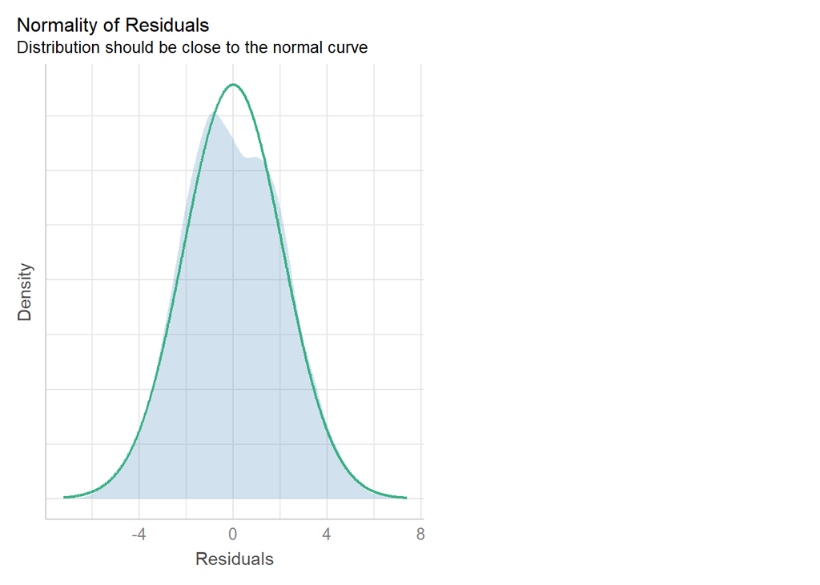

```r
check_model(mod, check = "normality")
```

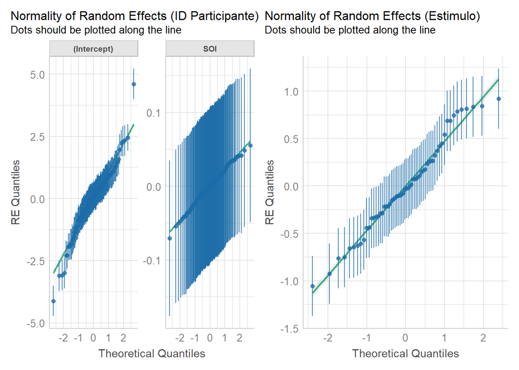

```r
check_model(mod, check = "reqq")
```

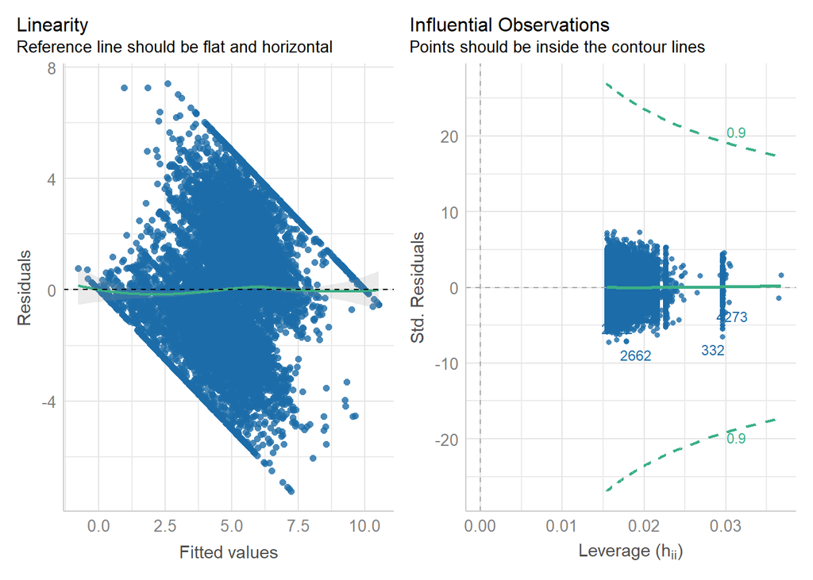

```r
check_model(mod, check = c("linearity", "outliers"))
```

### 3.2.2 Colinealidad

```r
kable(data.frame(vif(mod)),
      digits = 2,
      booktabs = TRUE,
      align = c("l", rep("c", 3)),
      linesep = "",
      caption = "Colinealidad",
      col.names = c("$GVIF$",
                    "$gl$",
                    "$GVIF^{(\\frac{1}{(2 \\times gl)})}$"),
      escape = FALSE) |>
    kable_classic("hover", full_width = FALSE)
```

Colinealidad

|  | $GVIF$ | $gl$ | $GVIF^{(\frac{1}{(2 \times gl)})}$ |
| --- | --- | --- | --- |
| SOI | 2.60 | 1 | 1.61 |
| Canal | 71.28 | 2 | 2.91 |
| Sexo | 2.77 | 1 | 1.67 |
| SOI:Canal | 168.46 | 2 | 3.60 |
| SOI:Sexo | 4.91 | 1 | 2.21 |
| Canal:Sexo | 144.41 | 2 | 3.47 |
| SOI:Canal:Sexo | 274.39 | 2 | 4.07 |

## 3.3 Resumen del modelo

```r
pval.lev <- function(pvals) {
  ifelse(pvals < 0.0001,
         "<b>< 0.0001</b>",
         ifelse(pvals < 0.001,
                "<b>< 0.001</b>",
                ifelse(pvals < 0.05,
                       paste0("<b>", round(pvals, 4), "</b>"),
                       round(pvals, 2))))
}

data.frame(anova(mod)) |>
    mutate(F.value = round(F.value, 2)) |>
    mutate(df = paste0(NumDF, ", ", round(DenDF, 2))) |>
    dplyr::select(F.value, df, Pr..F.) |>
    mutate(Pr..F. = pval.lev(Pr..F.)) |>
    rownames_to_column() |>
    mutate_at("rowname", str_replace_all, ":", " × ") |>
    kable(digits = 2,
          booktabs = TRUE,
          align = c("l", rep("c", 3)),
          linesep = "",
          caption = "Resumen del modelo",
          col.names = c("Efecto",
                        "$F$",
                        "$gl$",
                        "$p$"),
          escape = FALSE) |>
    kable_classic("hover", full_width = FALSE) |>
    footnote(general = paste0("$R^2_{condicional}$ = ",
                              round(r2_nakagawa(mod)$R2_conditional, 3),
                              ", $R^2_{marginal}$ = ",
                              round(r2_nakagawa(mod)$R2_marginal, 3),
                              ". Los efectos significativos están en negrita."),
             escape = FALSE,
             threeparttable = TRUE,
             footnote_as_chunk = TRUE,
             general_title = "Nota: ")
```

Resumen del modelo

| Efecto | $F$ | $gl$ | $p$ |
| --- | --- | --- | --- |
| SOI | 0.01 | 1, 57.22 | 0.91 |
| Canal | 18.72 | 2, 11846 | **< 0.0001** |
| Sexo | 2.71 | 1, 97.15 | 0.1 |
| SOI × Canal | 0.09 | 2, 11848.83 | 0.92 |
| SOI × Sexo | 2.28 | 1, 57.22 | 0.14 |
| Canal × Sexo | 6.48 | 2, 11846 | **0.0015** |
| SOI × Canal × Sexo | 11.17 | 2, 11848.83 | **< 0.0001** |

Nota: $R^2_{condicional}$ = 0.285, $R^2_{marginal}$ = 0.015. Los efectos significativos están en negrita.

## 3.4 Reporte en texto

```r
rep.mod <- report(mod, format = "markdown")
```

We fitted a linear mixed model (estimated using REML and BOBYQA optimizer) to predict Calificacion with SOI (formula: Calificacion ~ SOI * Canal * Sexo). The model included SOI as random effects (formula: list(~1 + SOI | ID Participante, ~1 | Estimulo)). The model’s total explanatory power is substantial (conditional R2 = 0.28) and the part related to the fixed effects alone (marginal R2) is of 0.02. The model’s intercept, corresponding to SOI = 0, is at 4.95 (95% CI [4.45, 5.46], t(12157) = 19.27, p < .001). Within this model:

- The effect of SOI is statistically significant and negative (beta = -0.16, 95% CI [-0.29, -0.02], t(12157) = -2.27, p = 0.023; Std. beta = -0.11, 95% CI [-0.20, -0.01])
- The effect of Canal [Voz] is statistically significant and positive (beta = 0.28, 95% CI [6.99e-03, 0.55], t(12157) = 2.01, p = 0.044; Std. beta = 0.31, 95% CI [0.25, 0.37])
- The effect of Canal [Voz + rostro] is statistically non-significant and positive (beta = 0.24, 95% CI [-0.03, 0.51], t(12157) = 1.74, p = 0.082; Std. beta = 0.24, 95% CI [0.18, 0.30])
- The effect of Sexo [Mujer] is statistically significant and negative (beta = -1.07, 95% CI [-1.87, -0.26], t(12157) = -2.59, p = 0.010; Std. beta = -0.03, 95% CI [-0.23, 0.18])
- The interaction effect of Canal [Voz] on SOI is statistically significant and positive (beta = 0.15, 95% CI [0.06, 0.23], t(12157) = 3.33, p < .001; Std. beta = 0.10, 95% CI [0.04, 0.16])
- The interaction effect of Canal [Voz + rostro] on SOI is statistically significant and positive (beta = 0.11, 95% CI [0.02, 0.19], t(12157) = 2.46, p = 0.014; Std. beta = 0.07, 95% CI [0.01, 0.13])
- The interaction effect of Sexo [Mujer] on SOI is statistically significant and positive (beta = 0.29, 95% CI [0.10, 0.48], t(12157) = 3.06, p = 0.002; Std. beta = 0.20, 95% CI [0.07, 0.33])
- The interaction effect of Sexo [Mujer] on Canal [Voz] is statistically significant and positive (beta = 0.83, 95% CI [0.38, 1.28], t(12157) = 3.60, p < .001; Std. beta = -0.05, 95% CI [-0.13, 0.03])
- The interaction effect of Sexo [Mujer] on Canal [Voz + rostro] is statistically non-significant and positive (beta = 0.45, 95% CI [-3.18e-03, 0.90], t(12157) = 1.95, p = 0.052; Std. beta = -0.08, 95% CI [-0.16, -1.61e-03])
- The interaction effect of Sexo [Mujer] on (SOI * Canal [Voz]) is statistically significant and negative (beta = -0.28, 95% CI [-0.40, -0.16], t(12157) = -4.63, p < .001; Std. beta = -0.19, 95% CI [-0.27, -0.11])
- The interaction effect of Sexo [Mujer] on (SOI * Canal [Voz + rostro]) is statistically significant and negative (beta = -0.19, 95% CI [-0.31, -0.07], t(12157) = -3.15, p = 0.002; Std. beta = -0.13, 95% CI [-0.21, -0.05])

Standardized parameters were obtained by fitting the model on a standardized version of the dataset. 95% Confidence Intervals (CIs) and p-values were computed using a Wald t-distribution approximation., We fitted a linear mixed model (estimated using REML and BOBYQA optimizer) to predict Calificacion with Canal (formula: Calificacion ~ SOI * Canal * Sexo). The model included SOI as random effects (formula: list(~1 + SOI | ID Participante, ~1 | Estimulo)). The model’s total explanatory power is substantial (conditional R2 = 0.28) and the part related to the fixed effects alone (marginal R2) is of 0.02. The model’s intercept, corresponding to Canal = Rostro, is at 4.95 (95% CI [4.45, 5.46], t(12157) = 19.27, p < .001). Within this model:

- The effect of SOI is statistically significant and negative (beta = -0.16, 95% CI [-0.29, -0.02], t(12157) = -2.27, p = 0.023; Std. beta = -0.11, 95% CI [-0.20, -0.01])
- The effect of Canal [Voz] is statistically significant and positive (beta = 0.28, 95% CI [6.99e-03, 0.55], t(12157) = 2.01, p = 0.044; Std. beta = 0.31, 95% CI [0.25, 0.37])
- The effect of Canal [Voz + rostro] is statistically non-significant and positive (beta = 0.24, 95% CI [-0.03, 0.51], t(12157) = 1.74, p = 0.082; Std. beta = 0.24, 95% CI [0.18, 0.30])
- The effect of Sexo [Mujer] is statistically significant and negative (beta = -1.07, 95% CI [-1.87, -0.26], t(12157) = -2.59, p = 0.010; Std. beta = -0.03, 95% CI [-0.23, 0.18])
- The interaction effect of Canal [Voz] on SOI is statistically significant and positive (beta = 0.15, 95% CI [0.06, 0.23], t(12157) = 3.33, p < .001; Std. beta = 0.10, 95% CI [0.04, 0.16])
- The interaction effect of Canal [Voz + rostro] on SOI is statistically significant and positive (beta = 0.11, 95% CI [0.02, 0.19], t(12157) = 2.46, p = 0.014; Std. beta = 0.07, 95% CI [0.01, 0.13])
- The interaction effect of Sexo [Mujer] on SOI is statistically significant and positive (beta = 0.29, 95% CI [0.10, 0.48], t(12157) = 3.06, p = 0.002; Std. beta = 0.20, 95% CI [0.07, 0.33])
- The interaction effect of Sexo [Mujer] on Canal [Voz] is statistically significant and positive (beta = 0.83, 95% CI [0.38, 1.28], t(12157) = 3.60, p < .001; Std. beta = -0.05, 95% CI [-0.13, 0.03])
- The interaction effect of Sexo [Mujer] on Canal [Voz + rostro] is statistically non-significant and positive (beta = 0.45, 95% CI [-3.18e-03, 0.90], t(12157) = 1.95, p = 0.052; Std. beta = -0.08, 95% CI [-0.16, -1.61e-03])
- The interaction effect of Sexo [Mujer] on (SOI * Canal [Voz]) is statistically significant and negative (beta = -0.28, 95% CI [-0.40, -0.16], t(12157) = -4.63, p < .001; Std. beta = -0.19, 95% CI [-0.27, -0.11])
- The interaction effect of Sexo [Mujer] on (SOI * Canal [Voz + rostro]) is statistically significant and negative (beta = -0.19, 95% CI [-0.31, -0.07], t(12157) = -3.15, p = 0.002; Std. beta = -0.13, 95% CI [-0.21, -0.05])

Standardized parameters were obtained by fitting the model on a standardized version of the dataset. 95% Confidence Intervals (CIs) and p-values were computed using a Wald t-distribution approximation., We fitted a linear mixed model (estimated using REML and BOBYQA optimizer) to predict Calificacion with Sexo (formula: Calificacion ~ SOI * Canal * Sexo). The model included SOI as random effects (formula: list(~1 + SOI | ID Participante, ~1 | Estimulo)). The model’s total explanatory power is substantial (conditional R2 = 0.28) and the part related to the fixed effects alone (marginal R2) is of 0.02. The model’s intercept, corresponding to Sexo = Hombre, is at 4.95 (95% CI [4.45, 5.46], t(12157) = 19.27, p < .001). Within this model:

- The effect of SOI is statistically significant and negative (beta = -0.16, 95% CI [-0.29, -0.02], t(12157) = -2.27, p = 0.023; Std. beta = -0.11, 95% CI [-0.20, -0.01])
- The effect of Canal [Voz] is statistically significant and positive (beta = 0.28, 95% CI [6.99e-03, 0.55], t(12157) = 2.01, p = 0.044; Std. beta = 0.31, 95% CI [0.25, 0.37])
- The effect of Canal [Voz + rostro] is statistically non-significant and positive (beta = 0.24, 95% CI [-0.03, 0.51], t(12157) = 1.74, p = 0.082; Std. beta = 0.24, 95% CI [0.18, 0.30])
- The effect of Sexo [Mujer] is statistically significant and negative (beta = -1.07, 95% CI [-1.87, -0.26], t(12157) = -2.59, p = 0.010; Std. beta = -0.03, 95% CI [-0.23, 0.18])
- The interaction effect of Canal [Voz] on SOI is statistically significant and positive (beta = 0.15, 95% CI [0.06, 0.23], t(12157) = 3.33, p < .001; Std. beta = 0.10, 95% CI [0.04, 0.16])
- The interaction effect of Canal [Voz + rostro] on SOI is statistically significant and positive (beta = 0.11, 95% CI [0.02, 0.19], t(12157) = 2.46, p = 0.014; Std. beta = 0.07, 95% CI [0.01, 0.13])
- The interaction effect of Sexo [Mujer] on SOI is statistically significant and positive (beta = 0.29, 95% CI [0.10, 0.48], t(12157) = 3.06, p = 0.002; Std. beta = 0.20, 95% CI [0.07, 0.33])
- The interaction effect of Sexo [Mujer] on Canal [Voz] is statistically significant and positive (beta = 0.83, 95% CI [0.38, 1.28], t(12157) = 3.60, p < .001; Std. beta = -0.05, 95% CI [-0.13, 0.03])
- The interaction effect of Sexo [Mujer] on Canal [Voz + rostro] is statistically non-significant and positive (beta = 0.45, 95% CI [-3.18e-03, 0.90], t(12157) = 1.95, p = 0.052; Std. beta = -0.08, 95% CI [-0.16, -1.61e-03])
- The interaction effect of Sexo [Mujer] on (SOI * Canal [Voz]) is statistically significant and negative (beta = -0.28, 95% CI [-0.40, -0.16], t(12157) = -4.63, p < .001; Std. beta = -0.19, 95% CI [-0.27, -0.11])
- The interaction effect of Sexo [Mujer] on (SOI * Canal [Voz + rostro]) is statistically significant and negative (beta = -0.19, 95% CI [-0.31, -0.07], t(12157) = -3.15, p = 0.002; Std. beta = -0.13, 95% CI [-0.21, -0.05])

Standardized parameters were obtained by fitting the model on a standardized version of the dataset. 95% Confidence Intervals (CIs) and p-values were computed using a Wald t-distribution approximation.

## 3.5 Explorar interacción Canal:SOI:Sexo

Calcular correlación entre sociosexualidad auto-reportada y estimada por canal y sexo

```r
slopes <- sim_slopes(mod,
                     pred = SOI,
                     modx = Canal,
                     mod2 = Sexo)

slopes.fin <- rbind(data.frame(slopes$slopes[1]),
             data.frame(slopes$slopes[2])) |>
  select(1,2,4,5,7) |>
  mutate(across(2:5, as.numeric)) |>
  mutate(across(2:5, round, 3)) |>
  mutate(Sexo = rep(c("Hombre", "Mujer"), each = 3)) |>
  select(6,1:5) |>
  rename(Canal = Value.of.Canal) |>
  rename(r = Est.)

slopes.audio <- filter(slopes.fin, Canal == "Voz")
slopes.audiovisual <- filter(slopes.fin, Canal == "Voz + rostro")
slopes.foto <- filter(slopes.fin, Canal == "Rostro")
```

### 3.5.1 Figura manual hecha con `ggplot2`

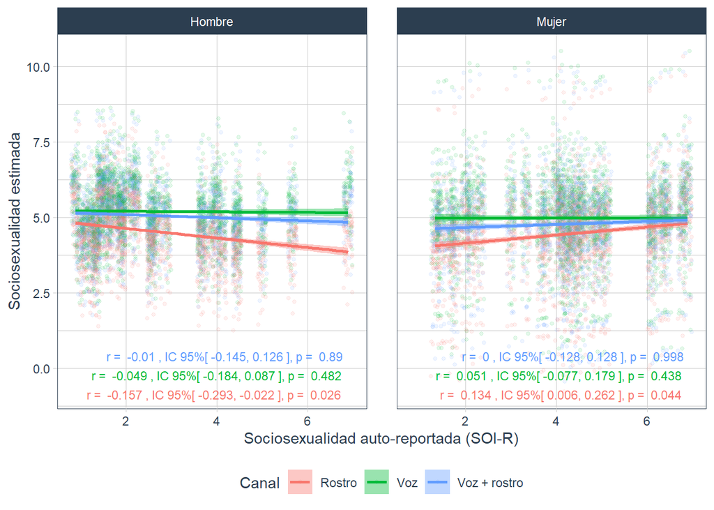

**Figura 1.** Efecto de la sociosexualidad auto-reportada (SOI-R) por los modelos en la Sociosexualidad estimada por los participantes, según canal y sexo.

```r
ggplot(mod@frame, aes(y = predict(mod), x = SOI, color = Canal, fill = Canal)) +
  geom_jitter(alpha = 0.1, size = 1, width = 0.1) +
  geom_smooth(method = "lm") +
  facet_wrap(~Sexo) +
  geom_text(data = slopes.audio,
            mapping = aes(x = Inf, y = -Inf,
            vjust = -5, hjust = 1.1),
            label = paste("r = ", slopes.audio$r,
                          ", IC 95%[", paste(slopes.audio$X2.5., slopes.audio$X97.5., sep = ", "),
                          "], p = ", slopes.audio$p),
            color = "#619CFF", size = 3) +
  geom_text(data = slopes.audiovisual,
            mapping = aes(x = Inf, y = -Inf,
            vjust = -3, hjust = 1.1),
            label = paste("r = ", slopes.audiovisual$r,
                          ", IC 95%[", paste(slopes.audiovisual$X2.5., slopes.audiovisual$X97.5., sep = ", "),
                          "], p = ", slopes.audiovisual$p),
            color = "#00BA38", size = 3) +
  geom_text(data = slopes.foto,
            mapping = aes(x = Inf, y = -Inf,
            vjust = -1, hjust = 1.1),
            label = paste("r = ", slopes.foto$r,
                          ", IC 95%[", paste(slopes.foto$X2.5., slopes.foto$X97.5., sep = ", "),
                          "], p = ", slopes.foto$p),
            color = "#F8766D", size = 3) +
  labs(x = "Sociosexualidad auto-reportada (SOI-R)",
       y = "Sociosexualidad estimada") +
  theme_tq()
```

# 4 Paquetes usados (se deben citar)

```r
sessionInf <- report(sessionInfo())
```

Analyses were conducted using the R Statistical language (version 4.2.2; R Core Team, 2022) on Windows 10 x64 (build 22000), using the packages equatiomatic (version 0.3.1; Anderson D et al., 2022), lme4 (version 1.1.31; Bates D et al., 2015), Matrix (version 1.5.1; Bates D et al., 2022), tidyquant (version 1.0.5; Dancho M, Vaughan D, 2022), car (version 3.1.1; Fox J, Weisberg S, 2019), carData (version 3.0.5; Fox J et al., 2022), lubridate (version 1.8.0; Grolemund G, Wickham H, 2011), lmerTest (version 3.1.3; Kuznetsova A et al., 2017), interactions (version 1.1.5; Long JA, 2019), performance (version 0.10.0; Lüdecke D et al., 2021), report (version 0.5.5; Makowski D et al., 2021), tibble (version 3.1.8; Müller K, Wickham H, 2022), PerformanceAnalytics (version 2.0.4; Peterson BG, Carl P, 2020), quantmod (version 0.4.20; Ryan JA, Ulrich JM, 2022), xts (version 0.12.2; Ryan JA, Ulrich JM, 2022), TTR (version 0.24.3; Ulrich J, 2021), ggplot2 (version 3.3.6; Wickham H, 2016), stringr (version 1.4.1; Wickham H, 2022), readxl (version 1.4.1; Wickham H, Bryan J, 2022), dplyr (version 1.0.10; Wickham H et al., 2022), tidyr (version 1.2.1; Wickham H, Girlich M, 2022), knitr (version 1.40; Xie Y, 2022), zoo (version 1.8.11; Zeileis A, Grothendieck G, 2005) and kableExtra (version 1.3.4; Zhu H, 2021).

## 4.1 References

- Anderson D, Heiss A, Sumners J (2022). *equatiomatic: Transform Modelsinto ‘LaTeX’ Equations*. R package version 0.3.1,https://CRAN.R-project.org/package=equatiomatic.
- Bates D, Mächler M, Bolker B, Walker S (2015). “Fitting LinearMixed-Effects Models Using lme4.” *Journal of Statistical Software*,*67*(1), 1-48. doi:10.18637/jss.v067.i01https://doi.org/10.18637/jss.v067.i01.
- Bates D, Maechler M, Jagan M (2022). *Matrix: Sparse and Dense MatrixClasses and Methods*. R package version 1.5-1,https://CRAN.R-project.org/package=Matrix.
- Dancho M, Vaughan D (2022). *tidyquant: Tidy Quantitative FinancialAnalysis*. R package version 1.0.5,https://CRAN.R-project.org/package=tidyquant.
- Fox J, Weisberg S (2019). *An R Companion to Applied Regression*, Thirdedition. Sage, Thousand Oaks CA.https://socialsciences.mcmaster.ca/jfox/Books/Companion/.
- Fox J, Weisberg S, Price B (2022). *carData: Companion to AppliedRegression Data Sets*. R package version 3.0-5,https://CRAN.R-project.org/package=carData.
- Grolemund G, Wickham H (2011). “Dates and Times Made Easy withlubridate.” *Journal of Statistical Software*, *40*(3), 1-25.https://www.jstatsoft.org/v40/i03/.
- Kuznetsova A, Brockhoff PB, Christensen RHB (2017). “lmerTest Package:Tests in Linear Mixed Effects Models.” *Journal of StatisticalSoftware*, *82*(13), 1-26. doi:10.18637/jss.v082.i13https://doi.org/10.18637/jss.v082.i13.
- Long JA (2019). *interactions: Comprehensive, User-Friendly Toolkit forProbing Interactions*. R package version 1.1.0,https://cran.r-project.org/package=interactions.
- Lüdecke D, Ben-Shachar M, Patil I, Waggoner P, Makowski D (2021).”performance: An R Package for Assessment, Comparison and Testing ofStatistical Models.” *Journal of Open Source Software*, *6*(60), 3139.doi:10.21105/joss.03139 https://doi.org/10.21105/joss.03139.
- Makowski D, Ben-Shachar M, Patil I, Lüdecke D (2021). “AutomatedResults Reporting as a Practical Tool to Improve Reproducibility andMethodological Best Practices Adoption.” *CRAN*.https://github.com/easystats/report.
- Müller K, Wickham H (2022). *tibble: Simple Data Frames*. R packageversion 3.1.8, https://CRAN.R-project.org/package=tibble.
- Peterson BG, Carl P (2020). *PerformanceAnalytics: Econometric Toolsfor Performance and Risk Analysis*. R package version 2.0.4,https://CRAN.R-project.org/package=PerformanceAnalytics.
- R Core Team (2022). *R: A Language and Environment for StatisticalComputing*. R Foundation for Statistical Computing, Vienna, Austria.https://www.R-project.org/.
- Ryan JA, Ulrich JM (2022). *quantmod: Quantitative Financial ModellingFramework*. R package version 0.4.20,https://CRAN.R-project.org/package=quantmod.
- Ryan JA, Ulrich JM (2022). *xts: eXtensible Time Series*. R packageversion 0.12.2, https://CRAN.R-project.org/package=xts.
- Ulrich J (2021). *TTR: Technical Trading Rules*. R package version0.24.3, https://CRAN.R-project.org/package=TTR.
- Wickham H (2016). *ggplot2: Elegant Graphics for Data Analysis*.Springer-Verlag New York. ISBN 978-3-319-24277-4,https://ggplot2.tidyverse.org.
- Wickham H (2022). *stringr: Simple, Consistent Wrappers for CommonString Operations*. R package version 1.4.1,https://CRAN.R-project.org/package=stringr.
- Wickham H, Bryan J (2022). *readxl: Read Excel Files*. R packageversion 1.4.1, https://CRAN.R-project.org/package=readxl.
- Wickham H, François R, Henry L, Müller K (2022). *dplyr: A Grammar ofData Manipulation*. R package version 1.0.10,https://CRAN.R-project.org/package=dplyr.
- Wickham H, Girlich M (2022). *tidyr: Tidy Messy Data*. R packageversion 1.2.1, https://CRAN.R-project.org/package=tidyr.
- Xie Y (2022). *knitr: A General-Purpose Package for Dynamic ReportGeneration in R*. R package version 1.40, https://yihui.org/knitr/.Xie Y (2015). *Dynamic Documents with R and knitr*, 2nd edition.Chapman and Hall/CRC, Boca Raton, Florida. ISBN 978-1498716963,https://yihui.org/knitr/.Xie Y (2014). “knitr: A Comprehensive Tool for Reproducible Research inR.” In Stodden V, Leisch F, Peng RD (eds.), *Implementing ReproducibleComputational Research*. Chapman and Hall/CRC. ISBN 978-1466561595,http://www.crcpress.com/product/isbn/9781466561595.
- Zeileis A, Grothendieck G (2005). “zoo: S3 Infrastructure for Regularand Irregular Time Series.” *Journal of Statistical Software*, *14*(6),1-27. doi:10.18637/jss.v014.i06https://doi.org/10.18637/jss.v014.i06.
- Zhu H (2021). *kableExtra: Construct Complex Table with ‘kable’ andPipe Syntax*. R package version 1.3.4,https://CRAN.R-project.org/package=kableExtra.